# Using Machine Learning to Predict the Quality of Exercise

Mark Schactman

March 20, 2016

## Introduction

Activity measurement devices are on everyone’s wrists these days (Jawbone, Fitbit, etc.).

These devices allow people to quantify how much of a particular activity they do, but they rarely quantify how well they do it. In this analysis, I used the data from accelerometers on the belt, forearm, arm, and dumbell of 6 participants. The participant performed barbell lifts correctly and then incorrectly in four different ways. These lifts were supervised by an experienced weight lifter to ensure the correct and incorrect lifts were all performed as required.

Many thanks to Velloso, et. al. for the data and detailed documentation.

Velloso, E.; Bulling, A.; Gellersen, H.; Ugulino, W.; Fuks, H. Qualitative Activity Recognition of Weight Lifting Exercises. Proceedings of 4th International Conference in Cooperation with SIGCHI (Augmented Human ’13) . Stuttgart, Germany: ACM SIGCHI, 2013.

http://groupware.les.inf.puc-rio.br/har

Questions to be answered are:  
1. How the model was built,  
2. How cross-validation was used,  
3. What the sample error is, and  
4. Why did I make the choices I did.

## Data

The training data has many summary statistics built into the dataset. However, the testing data does not have these variables. As such, it makes no sense to include these summary variables in the training models. After reducing the training data to the same variables as the testing data, there are 52 variables that can be used to predict the five types of lifts denoted in the data by the variable *classe*.

The 52 variables are actually 13 variables collected from each of four monitors (belt, arm, dumbell, and forearm).  
-roll  
-pitch  
-yaw  
-total acceleration  
-gyroscope (in the x, y, and z planes)  
-acceleration (in the x, y, and z planes), and  
-magnetometer (in the x, y, and z planes)

The training set is large (~19,000 records), so I decided to split the training set into training and validation sets to help better assess the out-of-sample error. This straightforward cross-validation technique seemed sufficient because of the size of the initial dataset.

The validation data will allow better assessment of accuracy of predictions on the small test set of 20 samples.

I checked the variability of each parameter using the near-zero variance function in R. No variable met this criteria, so I kept all 52 variables. I also computed the correlation between each pair of 52 variable to access colinearity. There are 1,326 pairs of variables (*52 x 51 / 2*). Among these pairs, only a small number have a correlation greater than 0.8. As such, I decided to leave all the variables in the models below.

```r
#Near zero variance
nzv <- nearZeroVar(train1, saveMetrics= TRUE)
nzv
```

```
##                      freqRatio percentUnique zeroVar   nzv
## roll_belt             1.055556    8.96635449   FALSE FALSE
## pitch_belt            1.000000   14.16926812   FALSE FALSE
## yaw_belt              1.003226   14.47277142   FALSE FALSE
## total_accel_belt      1.109388    0.23413111   FALSE FALSE
## gyros_belt_x          1.041772    1.07526882   FALSE FALSE
## gyros_belt_y          1.180793    0.57232050   FALSE FALSE
## gyros_belt_z          1.057765    1.40478668   FALSE FALSE
## accel_belt_x          1.039130    1.36142907   FALSE FALSE
## accel_belt_y          1.149203    1.16198404   FALSE FALSE
## accel_belt_z          1.087398    2.46271245   FALSE FALSE
## magnet_belt_x         1.112150    2.54942768   FALSE FALSE
## magnet_belt_y         1.056266    2.47138398   FALSE FALSE
## magnet_belt_z         1.094545    3.67672563   FALSE FALSE
## roll_arm             53.157895   19.67568505   FALSE FALSE
## pitch_arm            77.692308   22.57197364   FALSE FALSE
## yaw_arm              32.063492   21.79153659   FALSE FALSE
## total_accel_arm       1.083172    0.55497745   FALSE FALSE
## gyros_arm_x           1.019934    5.41970170   FALSE FALSE
## gyros_arm_y           1.538206    3.13041970   FALSE FALSE
## gyros_arm_z           1.107143    2.02913632   FALSE FALSE
## accel_arm_x           1.113208    6.52965661   FALSE FALSE
## accel_arm_y           1.155556    4.51786334   FALSE FALSE
## accel_arm_z           1.219178    6.55567118   FALSE FALSE
## magnet_arm_x          1.096154   11.33368019   FALSE FALSE
## magnet_arm_y          1.038462    7.36212279   FALSE FALSE
## magnet_arm_z          1.089552   10.80471731   FALSE FALSE
## roll_dumbbell         1.164384   87.44363510   FALSE FALSE
## pitch_dumbbell        2.176471   85.47519945   FALSE FALSE
## yaw_dumbbell          1.133333   86.52445369   FALSE FALSE
## total_accel_dumbbell  1.049444    0.36420395   FALSE FALSE
## gyros_dumbbell_x      1.016620    2.00312175   FALSE FALSE
## gyros_dumbbell_y      1.257703    2.27193895   FALSE FALSE
## gyros_dumbbell_z      1.059701    1.68227541   FALSE FALSE
## accel_dumbbell_x      1.044554    3.45993757   FALSE FALSE
## accel_dumbbell_y      1.117241    3.85882761   FALSE FALSE
## accel_dumbbell_z      1.078014    3.43392300   FALSE FALSE
## magnet_dumbbell_x     1.018182    9.00104058   FALSE FALSE
## magnet_dumbbell_y     1.231481    7.04127645   FALSE FALSE
## magnet_dumbbell_z     1.009174    5.68851890   FALSE FALSE
## roll_forearm         11.607143   14.88900451   FALSE FALSE
## pitch_forearm        56.825000   21.37530350   FALSE FALSE
## yaw_forearm          15.255034   14.11723899   FALSE FALSE
## total_accel_forearm   1.058433    0.57232050   FALSE FALSE
## gyros_forearm_x       1.055738    2.35865418   FALSE FALSE
## gyros_forearm_y       1.035874    6.13076656   FALSE FALSE
## gyros_forearm_z       1.176259    2.48005550   FALSE FALSE
## accel_forearm_x       1.039216    6.70308706   FALSE FALSE
## accel_forearm_y       1.066667    8.44606313   FALSE FALSE
## accel_forearm_z       1.093750    4.74332293   FALSE FALSE
## magnet_forearm_x      1.020833   12.33957683   FALSE FALSE
## magnet_forearm_y      1.176471   15.59139785   FALSE FALSE
## magnet_forearm_z      1.027027   13.70967742   FALSE FALSE
## classe                1.471537    0.04335761   FALSE FALSE
```

```r
#Pairs of variables with high correlation
c <- cor(train1[,1:52], use="complete.obs", method="pearson")
cc <- c[c > 0.8 & c != 1]
ccc <- length(cc)/2
ccc
```

```
## [1] 9
```

As an assessment of predictive power of the variables, I plotted each of the belt measurements for each of the five types of exercise. The *gyroscopic* variables seem quite similar across the exercise types, while *roll* and *yaw* look different and should be important predictors.

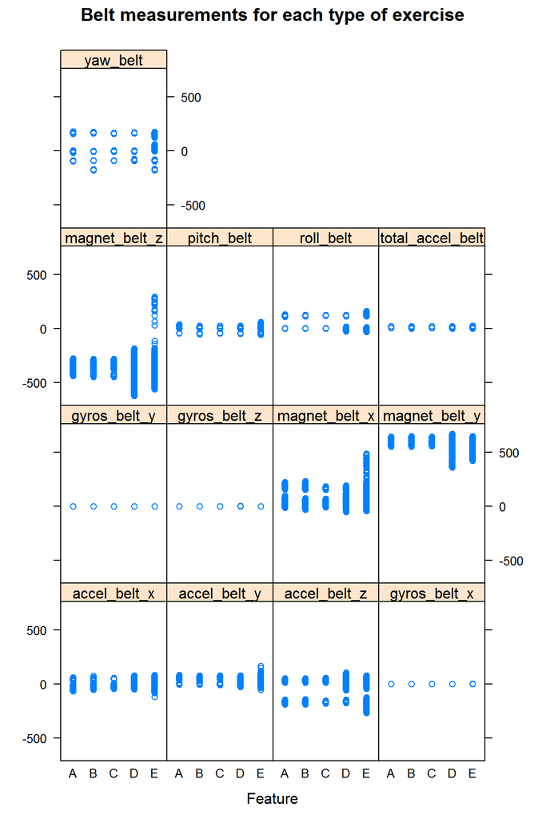

## Modelling

My approach to the modelling was to attempt three types of models on the training data and then assess the out-of-sample variance using the validation data. These models (appropriate for a categorical outcome variable) are:  
-gradient boosted model  
-random forest  
-linear discriminant analysis

If needed to improve the accuracy of the prediction, I could create a final model using random forests using the results of the predicted results from the first three models. This *stacked* model should improve the overall accuracy of the prediction.

### Gradient Boosted Model

The GBM model is higly accurate as seen below from the confusion matrix on the validation data.

```r
#Gradient boosted model
zgbm <- train(classe ~ ., data=train1, method="gbm", verbose=FALSE)

zzgbm_pred <- predict(zgbm, newdata=valid1)
cm_gbm <- confusionMatrix(zzgbm_pred, valid1$classe)
cm_gbm
```

```
## Confusion Matrix and Statistics
##
##           Reference
## Prediction    A    B    C    D    E
##          A 2143   47    0    2    4
##          B   32 1398   44    1   18
##          C    6   34 1279   37    8
##          D    7    6   12 1215   11
##          E    0    2    5    3 1370
##
## Overall Statistics
##
##                Accuracy : 0.9637
##                  95% CI : (0.9593, 0.9678)
##     No Information Rate : 0.2847
##     P-Value [Acc > NIR] : < 2.2e-16
##
##                   Kappa : 0.9541
##  Mcnemar's Test P-Value : 1.539e-07
##
## Statistics by Class:
##
##                      Class: A Class: B Class: C Class: D Class: E
## Sensitivity            0.9794   0.9401   0.9545   0.9658   0.9709
## Specificity            0.9904   0.9847   0.9866   0.9944   0.9984
## Pos Pred Value         0.9759   0.9364   0.9377   0.9712   0.9928
## Neg Pred Value         0.9918   0.9856   0.9903   0.9933   0.9935
## Prevalence             0.2847   0.1935   0.1744   0.1637   0.1836
## Detection Rate         0.2789   0.1819   0.1664   0.1581   0.1783
## Detection Prevalence   0.2858   0.1943   0.1775   0.1628   0.1796
## Balanced Accuracy      0.9849   0.9624   0.9705   0.9801   0.9847
```

The accuracy on the validation data is 0.964.

### Random Forest

The random forest results model was also highly accurate based on the out-of-bag error rate as well as the accuracy on the prediction data.

```r
#Random forests
zrf <- train(classe ~ ., data=train1, method="rf", importance=T)
zrf$finalModel
```

```
##
## Call:
##  randomForest(x = x, y = y, mtry = param$mtry, importance = ..1)
##                Type of random forest: classification
##                      Number of trees: 500
## No. of variables tried at each split: 27
##
##         OOB estimate of  error rate: 0.75%
## Confusion matrix:
##      A    B    C    D    E  class.error
## A 3280    2    1    0    0 0.0009137984
## B   18 2207    6    0    0 0.0107575078
## C    0    8 1992   12    0 0.0099403579
## D    0    0   22 1866    1 0.0121757544
## E    0    2    3   12 2100 0.0080302315
```

```r
zzrf_pred <- predict(zrf, newdata=valid1)
cm_rf <- confusionMatrix(zzrf_pred, valid1$classe)
cm_rf
```

```
## Confusion Matrix and Statistics
##
##           Reference
## Prediction    A    B    C    D    E
##          A 2184   14    0    0    0
##          B    3 1466   10    0    0
##          C    0    7 1327   12    2
##          D    0    0    3 1245    1
##          E    1    0    0    1 1408
##
## Overall Statistics
##
##                Accuracy : 0.993
##                  95% CI : (0.9908, 0.9947)
##     No Information Rate : 0.2847
##     P-Value [Acc > NIR] : < 2.2e-16
##
##                   Kappa : 0.9911
##  Mcnemar's Test P-Value : NA
##
## Statistics by Class:
##
##                      Class: A Class: B Class: C Class: D Class: E
## Sensitivity            0.9982   0.9859   0.9903   0.9897   0.9979
## Specificity            0.9975   0.9979   0.9967   0.9994   0.9997
## Pos Pred Value         0.9936   0.9912   0.9844   0.9968   0.9986
## Neg Pred Value         0.9993   0.9966   0.9979   0.9980   0.9995
## Prevalence             0.2847   0.1935   0.1744   0.1637   0.1836
## Detection Rate         0.2842   0.1908   0.1727   0.1620   0.1832
## Detection Prevalence   0.2860   0.1925   0.1754   0.1625   0.1835
## Balanced Accuracy      0.9978   0.9919   0.9935   0.9945   0.9988
```

The accuracy is 0.993.  
Variable importance is plotted below.

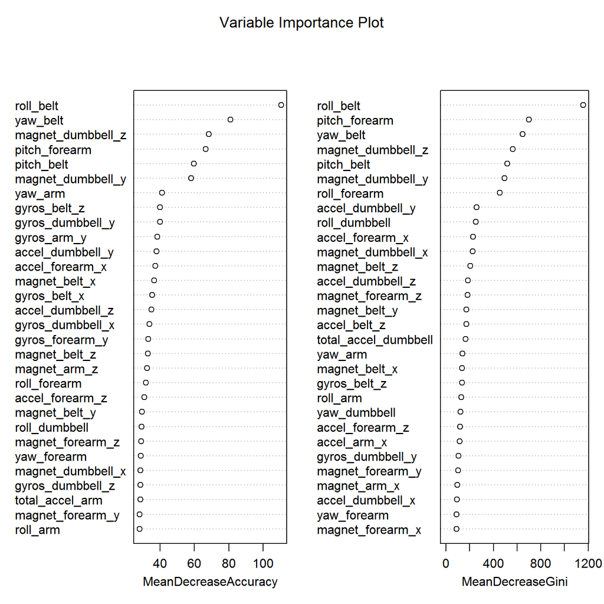

### Linear Discriminant Analysis

The LDA was the least accurate of the models.

```r
#LDA
zlda <- train(classe ~ ., data=train1, method="lda")
#fancyRpartPlot(zlda$finalModel)

zzlda_pred <- predict(zlda, newdata=valid1)
cm_lda <- confusionMatrix(zzlda_pred, valid1$classe)
cm_lda
```

```
## Confusion Matrix and Statistics
##
##           Reference
## Prediction    A    B    C    D    E
##          A 1776  227  137   72   50
##          B   54  948  123   51  226
##          C  177  190  890  163  132
##          D  172   62  156  925  148
##          E    9   60   34   47  855
##
## Overall Statistics
##
##                Accuracy : 0.702
##                  95% CI : (0.6916, 0.7122)
##     No Information Rate : 0.2847
##     P-Value [Acc > NIR] : < 2.2e-16
##
##                   Kappa : 0.623
##  Mcnemar's Test P-Value : < 2.2e-16
##
## Statistics by Class:
##
##                      Class: A Class: B Class: C Class: D Class: E
## Sensitivity            0.8117   0.6375   0.6642   0.7353   0.6060
## Specificity            0.9116   0.9267   0.8956   0.9163   0.9761
## Pos Pred Value         0.7851   0.6762   0.5735   0.6323   0.8507
## Neg Pred Value         0.9240   0.9142   0.9266   0.9465   0.9168
## Prevalence             0.2847   0.1935   0.1744   0.1637   0.1836
## Detection Rate         0.2311   0.1234   0.1158   0.1204   0.1113
## Detection Prevalence   0.2944   0.1825   0.2020   0.1904   0.1308
## Balanced Accuracy      0.8616   0.7821   0.7799   0.8258   0.7910
```

The accuracy on the validation data is 0.702.

### Stacked analysis

The last step in building the prediction model is to combine the predictions from the three previous models and use a random forest approach to build a final model. The results are below.

```r
pred <- data.frame(zzrf_pred, zzgbm_pred, zzlda_pred, classe=valid1$classe)
stack <- train(classe~., data=pred, method="rf")
test_pred <- predict(stack, pred)
cm_stack <- confusionMatrix(test_pred, valid1$classe)
cm_stack
```

```
## Confusion Matrix and Statistics
##
##           Reference
## Prediction    A    B    C    D    E
##          A 2184   14    0    0    0
##          B    3 1466   10    0    0
##          C    0    7 1327   12    2
##          D    0    0    3 1245    1
##          E    1    0    0    1 1408
##
## Overall Statistics
##
##                Accuracy : 0.993
##                  95% CI : (0.9908, 0.9947)
##     No Information Rate : 0.2847
##     P-Value [Acc > NIR] : < 2.2e-16
##
##                   Kappa : 0.9911
##  Mcnemar's Test P-Value : NA
##
## Statistics by Class:
##
##                      Class: A Class: B Class: C Class: D Class: E
## Sensitivity            0.9982   0.9859   0.9903   0.9897   0.9979
## Specificity            0.9975   0.9979   0.9967   0.9994   0.9997
## Pos Pred Value         0.9936   0.9912   0.9844   0.9968   0.9986
## Neg Pred Value         0.9993   0.9966   0.9979   0.9980   0.9995
## Prevalence             0.2847   0.1935   0.1744   0.1637   0.1836
## Detection Rate         0.2842   0.1908   0.1727   0.1620   0.1832
## Detection Prevalence   0.2860   0.1925   0.1754   0.1625   0.1835
## Balanced Accuracy      0.9978   0.9919   0.9935   0.9945   0.9988
```

## Predicting from the test set

The final step is to use the stacked model to predict results from the small test set of 20 samples. I have also printed the results from the three individual models.

```r
test1 <- predict(zrf, test)
test2 <- predict(zgbm, test)
test3 <- predict(zlda, test)
testall <- data.frame(zzrf_pred=test1, zzgbm_pred=test2, zzlda_pred=test3)

#Individual model predictions
testall
```

```
##    zzrf_pred zzgbm_pred zzlda_pred
## 1          B          B          B
## 2          A          A          A
## 3          B          B          B
## 4          A          A          C
## 5          A          A          C
## 6          E          E          E
## 7          D          D          D
## 8          B          B          D
## 9          A          A          A
## 10         A          A          A
## 11         B          B          D
## 12         C          C          A
## 13         B          B          B
## 14         A          A          A
## 15         E          E          E
## 16         E          E          A
## 17         A          A          A
## 18         B          B          B
## 19         B          B          B
## 20         B          B          B
```

```r
#Stacked model predictions
pred20 <- predict(stack, testall)
pred20
```

```
##  [1] B A B A A E D B A A B C B A E E A B B B
## Levels: A B C D E
```